# Ass_2

Simba

11/28/2020

Assignment 2

Prompt:

Prepare a report analyzing education outcomes in one County (of your choice) in the Bay Area. You are welcome to include as many data-driven insights as you’d like, with the many kinds of education datasets available from the Census Bureau and elsewhere, but at the minimum, you must include:

An equity analysis of educational attainment by race. Plot the “stacked” and “filled” bar charts as demonstrated in 2.2; from there, you are welcome to add as many comments and supplementary visualizations as you’d like. Essentially, respond to the question: “Is there disproportionate education attainment by race in the County?” Note that the universe of the ACS datasets on educational attainment is “population 25 years or older”, so be sure to clarify that in your visuals and commentary.

An estimate of the number and percentage of K-12 students who have no internet access at home, using the latest available PUMS data. (Note that 2019 1-yr PUMS data will be available in mid-October 2020, so you might choose to update your analysis using that data at that time.) State your assumptions clearly, especially how useful the available data is for understanding the challenges of remote learning in 2020. Include a map of this metric for all PUMAs in the Bay Area.

1. Equity Analysis of Educational Attainment by Race

For the purpose of this assignment, the 5 year acs data set was first extracted and organized as below. Napa (#=055) county was selected as the subject of study here. The educational attainment for people older than 25 years old dataset was used here.

```r
acs_vars_2018_5yr <-
  listCensusMetadata(
    name = "2018/acs/acs5",
    type = "variables"
  )
```

```r
#napa white alone education 5 years
napa_edu_white <-
  getCensus(
    name = "acs/acs5",
    vintage = 2018,
    region = "county:055",
    regionin = "state:06",
    vars = "group(C15002A)"
  ) %>% select(!c(GEO_ID,state,NAME) & !ends_with(c("EA","MA","M"))) %>%
  pivot_longer(
    ends_with("E"),
    names_to = "variable",
    values_to = "estimate"
  ) %>%
  left_join(
    acs_vars_2018_5yr %>%
      select(name, label),
    by = c("variable" = "name")
  )  %>% select(-variable)  %>%
  separate(
    label,
    into = c(NA,NA,NA,"education"),
    sep = "!!"
  ) %>%
  filter(!is.na(education)) %>% group_by(education) %>% summarise(estimate = sum(estimate))
view(napa_edu_white)
```

```r
census_race_labels <- data.frame(
  code = c("A","B","C","D","E","F","G"),
  label =
    c(
      "White Alone",
      "Black or African American",
      "American Indian and Alaska Native Alone",
      "Asian Alone",
      "Native Hawaiian and Other Pacific Islander Alone)",
      "Some Other Race Alone",
      "Two or More Races"
    )
)

census_race_labels <-
  c(
    "White Alone",
    "Black or African American",
    "American Indian and Alaska Native Alone",
    "Asian Alone",
    "Native Hawaiian and Other Pacific Islander Alone)",
    "Some Other Race Alone",
    "Two or More Races"
  )

napa_edu1_race <-
  1:7 %>%
  map_dfr(function(x){
    getCensus(
      name = "acs/acs5",
      vintage = 2018,
      region = "county:055",
      regionin = "state:06",
      vars = paste0("group(C15002",LETTERS[x],")")
    ) %>%
      select(!c(GEO_ID,state,NAME) & !ends_with(c("EA","MA","M"))) %>%
      pivot_longer(
        ends_with("E"),
        names_to = "variable",
        values_to = "estimate"
      ) %>%
      left_join(
        acs_vars_2018_5yr %>%
          select(name, label),
        by = c("variable" = "name")
      ) %>%
      select(-variable) %>%
     separate(label,into = c(NA,NA,NA,"education"),sep = "!!") %>%
  filter(!is.na(education)) %>%
      mutate(race = census_race_labels[x])
  }) %>% group_by(county,education, race,)
  napa_edu_race<-
    summarize(napa_edu1_race,
              tot_est =
                sum(estimate,na.rm = T))
```

Now proceed to results plotting.

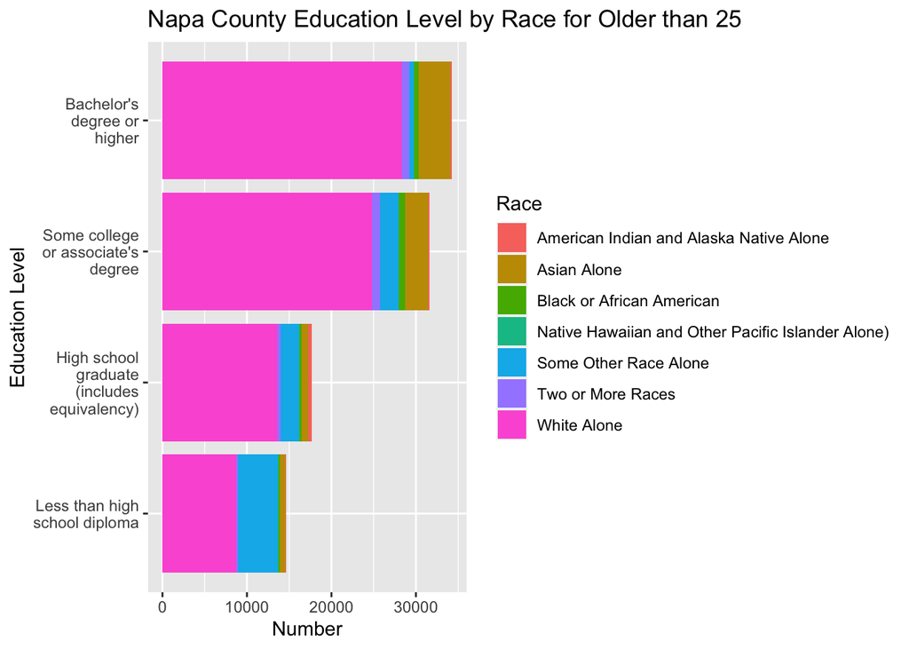

```r
level_order <- c('Less than high school diploma', 'High school graduate (includes equivalency)', "Some college or associate's degree", "Bachelor's degree or higher")

napa_edu_race %>%
  group_by(education, race) %>%
  summarize(tot_est = sum(tot_est)) %>%
  ggplot() +
  geom_bar(
    aes(
      x = factor(education, level=level_order),
      y = tot_est,
      fill = race
    ),
    stat = "identity",
    position = "stack"
  ) +
  labs(
    x = "Education Level",
    y = "Number",
    title = "Napa County Education Level by Race for Older than 25",
    fill = "Race"
  )+
  coord_flip() + scale_x_discrete(labels=scales::wrap_format(15))
```

```r
level_order <- c('Less than high school diploma', 'High school graduate (includes equivalency)', "Some college or associate's degree", "Bachelor's degree or higher", "Total")

napa_race_total <-
  napa_edu_race%>%
  group_by(race) %>%
  summarize(tot_est = sum(tot_est)) %>%
  mutate(education = "Total")
```

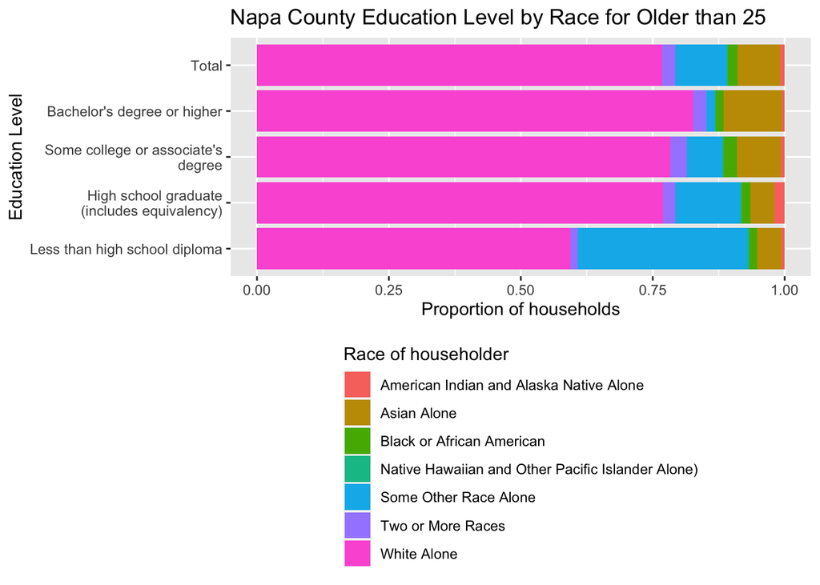

```r
napa_edu_race %>%
  group_by(education, race) %>%
  summarize(tot_est = sum(tot_est), na.rm = F) %>%
  rbind(napa_race_total) %>%
  ggplot() +
  geom_bar(
    aes(
      x = factor(education, level=level_order),
      y = tot_est,
      fill = race
    ),
    stat = "identity",
    position = "fill"
  ) +
  labs(
    x = "Education Level",
    y = "Proportion of households",
    title = "Napa County Education Level by Race for Older than 25",
    fill = "Race of householder"
  ) +
  coord_flip() +
  theme(
    legend.position = "bottom",
    legend.direction = "vertical"
  )+ scale_x_discrete(labels=scales::wrap_format(30))
```

From either the proportion or the number graph, it can be observed that the proportion and the number of white people with go up when with higher education levels. Similarly, an increase in the number and proportion of Asian population as the education level goes higher can also be observed. Since this dataset is targeted on the portion of people older than 25 years, it is reasonable to assume that most of the people surveyed have already finished their education desired. On the other hand, black and African population remains about the same portion at each education level.

When compared with the over all race distribution of the Napa County, we can observe that while around 76% of the Napa population is white, at the level of people with less than high school diploma, almost 40 % of the subpopulation is non-white. Therefore, the non-white population is more likely to only possess less than high school degree in the Napa County. For the subpopulation that are with high school degree and some college/associate’s degree, the proportion of white and non-white largely match with that of the overall rave proportion. At the level of Bachelor’s degree or higher, white and Asian population are also observed to be more likely to attain when compared to the overall population distribution.

2. Migration Analysis: A migration analysis, as demonstrated in 2.3, using data on educational attainment. Discuss what you believe can be interpreted from the results of this methodology, especially as it relates to the “educational mobility” of Bay Area residents.

```r
acs_vars_2019_1yr <-
  listCensusMetadata(
    name = "2019/acs/acs1",
    type = "variables"
  )
```

```r
napa_mob_current_19  <-
  getCensus(
    name = "acs/acs1",
    vintage = 2019,
    region = "county:055",
    regionin = "state:06",
    vars = c("group(B07009)")
  ) %>%
  select(!c(GEO_ID,state,NAME) & !ends_with(c("EA","MA","M"))) %>%
  pivot_longer(
    ends_with("E"),
    names_to = "variable",
    values_to = "estimate"
  ) %>%
  left_join(
    acs_vars_2019_1yr %>%
      select(name, label),
    by = c("variable" = "name")
  ) %>%
  select(-variable) %>%
  separate(
    label,
    into = c(NA,NA,"mobility","education",NA),
    sep = "!!"
  ) %>%
  mutate(
    mobility = ifelse(
      mobility %in% c("Same house 1 year ago:", "Moved within same county:"),
      "Here since last year",
      "Inflow"
    )
  ) %>%
  filter(!is.na(education)) %>%
  group_by(mobility, education) %>%
  summarize(estimate = sum(estimate))
napa_mob_lastyear_19 <-
    getCensus(
    name = "acs/acs1",
    vintage = 2019,
    region = "county:055",
    regionin = "state:06",
    vars = c("group(B07409)")
  ) %>%
  select(!c(GEO_ID,state,NAME) & !ends_with(c("EA","MA","M"))) %>%
  pivot_longer(
    ends_with("E"),
    names_to = "variable",
    values_to = "estimate"
  ) %>%
  left_join(
    acs_vars_2019_1yr %>%
      select(name, label),
    by = c("variable" = "name")
  ) %>%
  select(-variable) %>%
  separate(
    label,
    into = c(NA,NA,"mobility","education",NA),
    sep = "!!"
  ) %>%
  mutate(
    mobility = ifelse(
      mobility %in% c("Same house:", "Moved within same county:"),
      "Here since last year",
      "Outflow"
    )
  ) %>%
  filter(!is.na(education)) %>%
  group_by(mobility, education) %>%
  summarize(estimate = sum(estimate))
acs_vars_2018_1yr <-
  listCensusMetadata(
    name = "2018/acs/acs1",
    type = "variables")
```

```r
napa_mob_current_18 <-
 getCensus(
    name = "acs/acs1",
    vintage = 2018,
    region = "county:055",
    regionin = "state:06",
    vars = c("group(B07009)")
  ) %>%
  select(!c(GEO_ID,state,NAME) & !ends_with(c("EA","MA","M"))) %>%
  pivot_longer(
    ends_with("E"),
    names_to = "variable",
    values_to = "estimate"
  ) %>%
  left_join(
    acs_vars_2019_1yr %>%
      select(name, label),
    by = c("variable" = "name")
  ) %>%
  select(-variable) %>%
  separate(
    label,
    into = c(NA,NA,"mobility","education",NA),
    sep = "!!"
  ) %>%  mutate(
    mobility = "Here last year"
  ) %>%
  filter(!is.na(education)) %>%
  group_by(mobility, education) %>%
  summarize(estimate = sum(estimate))
napa_edu_flows_19 <-
  rbind(
    napa_mob_current_18,
    napa_mob_lastyear_19 %>%
      filter(mobility == "Outflow"),
    napa_mob_current_19 %>%
      filter(mobility == "Inflow"),
    napa_mob_current_19 %>%
      group_by(education) %>%
      summarize(estimate = sum(estimate)) %>%
      mutate(mobility = "Here this year")
  ) %>%
  pivot_wider(
    names_from = mobility,
    values_from = estimate
  ) %>%
  mutate(
    `External net` = Inflow - Outflow,
    `Internal net` = `Here this year` - `Here last year` - `External net`,
  ) %>%
  select(
    `Education Attainment` = education,
    `Internal net`,
    `External net`,
    `Here last year`,
    `Here this year`,
    Outflow,
    Inflow
  )
napa_edu_flows_19
```

```
## # A tibble: 5 x 7
##   `Education Atta… `Internal net` `External net` `Here last year`
##   <chr>                     <dbl>          <dbl>            <dbl>
## 1 Bachelor's degr…          -2258            749            23099
## 2 Graduate or pro…           1412           1333            10985
## 3 High school gra…            -96           -440            18497
## 4 Less than high …            384           -147            13943
## 5 Some college or…           -919           -114            31238
## # … with 3 more variables: `Here this year` <dbl>, Outflow <dbl>, Inflow <dbl>
```

From this migration analysis, we can observe that there is an overall outflow for the subpopulation with some college or associate degree or lower level education and an inflow for people with Bachelor degree or higher. This can be associated with the technology industry in the bay area and the rise in housing prices.

3. PUMAS data analysis: An estimate of the number and percentage of K-12 students who have no internet access at home, using the latest available PUMS data. (Note that 2019 1-yr PUMS data will be available in mid-October 2020, so you might choose to update your analysis using that data at that time.) State your assumptions clearly, especially how useful the available data is for understanding the challenges of remote learning in 2020. Include a map of this metric for all PUMAs in the Bay Area.

After observing the available PUMS one year data of 2019, it was concluded that the percentage and number of K-12 students can only analyzed down to a household level regarding their access to internet since the access to internet is only provided at household level, and consequently influence on educational attainment under the circumstances of covid-19. Therefore, the data organization and computations included below are not specified to individual student level but only household level.

```r
pums_vars_2019 <-
  pums_variables %>%
  filter(year == 2019, survey == "acs1")
pums_vars_2019_distinct_hh <-
  pums_vars_2019 %>%
  distinct(var_code, var_label, data_type, level) %>%
  filter(level == "housing")
```

```r
ca_pums_r <- get_pums(
  variables = c(
    "PUMA",
    "ACCESS",
    "FPARC", #Family presence and age of related children
    "HUPAC", #HH presence and age of children
    "NOC",#Number of own children in household (unweighted)
    "NRC" #Number of related children in household (unweighted)
  ),
  state = "CA",
  year = 2019,
  survey = "acs1",
  recode = T
)
```

[output not shown]

[output cut: 12474 more lines]

[output not shown]

```r
bay_county_names <-
  c(
    "Alameda",
    "Contra Costa",
    "Marin",
    "Napa",
    "San Francisco",
    "San Mateo",
    "Santa Clara",
    "Solano",
    "Sonoma"
  )

napa_name<-c("Napa")

bay_counties <-
  counties("CA", cb = T, progress_bar = F) %>%
  filter(NAME %in% bay_county_names)

napa_county <-
  counties("CA", cb = T, progress_bar = F) %>%
  filter(NAME %in% napa_name)

ca_pumas <-
  pumas("CA", cb = T, progress_bar = F)

bay_pumas <- #FOR GENERAL USE
  ca_pumas %>%
  st_centroid() %>%
  .[bay_counties, ] %>%
  st_set_geometry(NULL) %>%
  left_join(ca_pumas %>% select(GEOID10)) %>%
  st_as_sf()
```

```
## although coordinates are longitude/latitude, st_intersects assumes that they are planar
## although coordinates are longitude/latitude, st_intersects assumes that they are planar
```

```r
napa_pumas <- # FOR GENERAL USE
  ca_pumas %>%
  st_centroid() %>%
  .[napa_county, ] %>%
  st_set_geometry(NULL) %>%
  left_join(ca_pumas %>% select(GEOID10)) %>%
  st_as_sf()
```

```
## although coordinates are longitude/latitude, st_intersects assumes that they are planar
```

```
## although coordinates are longitude/latitude, st_intersects assumes that they are planar
```

```r
# FOR THIS CASE
bay_pums_r <-
  ca_pums_r %>%
  filter(PUMA %in% bay_pumas$PUMACE10)

napa_pums_r <-
  ca_pums_r %>% filter(PUMA %in% napa_pumas$PUMACE10)
```

```r
napa_access <-
  napa_pums_r %>%
  filter(!duplicated(SERIALNO)) %>%
  mutate(
    withkid_noaccess = ifelse(
      (ACCESS_label == "No access to the Internet at this house, apartment, or mobile home") &
        (FPARC_label %in% c("With related children 5 to 17 years only","With related children under 5 years only")),
      WGTP,
      0
    )
  ) %>%
  group_by(PUMA) %>%
  summarize(
    perc_withkid_noaccess =
      sum(withkid_noaccess, na.rm =T)/sum(WGTP, na.rm = T)*100,
    withkid_noaccess = sum(withkid_noaccess, na.rm =T)
  )
bay_access <-
  bay_pums_r %>%
  filter(!duplicated(SERIALNO)) %>%
  mutate(
    withkid_noaccess = ifelse(
      (ACCESS_label == "No access to the Internet at this house, apartment, or mobile home") &
        (FPARC_label %in% c("With related children 5 to 17 years only","With related children under 5 years only")),
      WGTP,
      0
    )
  ) %>%
  group_by(PUMA) %>%
  summarize(
    perc_withkid_noaccess =
      sum(withkid_noaccess, na.rm =T)/sum(WGTP, na.rm = T)*100
  ) %>%
  left_join(
    bay_pumas %>%
      select(PUMACE10),
    by = c("PUMA" = "PUMACE10")
  ) %>%
  st_as_sf()
pums_pal <- colorNumeric(
  palette = "Blues",
  domain = bay_access$perc_withkid_noaccess
)

leaflet() %>%
  addTiles() %>%
  addPolygons(
    data = bay_access,
    fillColor = ~pums_pal(perc_withkid_noaccess),
    color = "white",
    opacity = 0.5,
    fillOpacity = 0.5,
    weight = 1,
    label = ~paste0(
      round(perc_withkid_noaccess),
      "% households with K-12 children without internet access"
    ),
    highlightOptions = highlightOptions(
      weight = 2,
      opacity = 1
    )
  ) %>%
  addLegend(
    data = bay_access,
    pal = pums_pal,
    values = ~perc_withkid_noaccess,
    title = "% households with K-12<br> children without internet access"
  )
```

[interactive chart not shown]

Above is a chart for households with K12 students and no access to internet in the bay area, showing that for most area of the bay area, the percentage of the k12 students with no access to the internet is below 3%, mostly below 2%. The percentage of Napa is close to 0 percent. Two areas have obviously higher percentage with no access to the internet, around San Leandro and San Jose. If possible, a individual level dataset can be more helpful in estimating the number of percentage of K12 students with no access to internet and how convenient for them to access remote education.